# Kickstarter Projects Analysis

Sarah AlQahtani

10/11/2020

## What is Kickstarter?

[figure not shown]

Kickstarter is a funding platform for creative projects. Everything from film, games, and music to art, design, and technology. Kickstarter is full of ambitious, innovative, and imaginative projects that are brought to life through the direct support of others.

Every project creator sets their project’s funding goal and deadline. If people like the project, they can pledge money to make it happen. If the project succeeds in reaching its funding goal, all backers’ credit cards are charged when time expires. Funding on Kickstarter is all-or-nothing. If the project falls short of its funding goal, no one is charged.

If a project is successfully funded, Kickstarter applies a 5% fee to the funds collected.

## 1. Description of Kickstarters Dataset

```r
#Read in the data
kickstarter <- read.csv("datasets/ks-projects-201801.csv")
# Print out the head
datatable(head(kickstarter),fillContainer = TRUE)
```

|  | ID | name | category | main_category | currency | deadline | goal | launched | pledged | state | backers | country | usd.pledged | usd_pledged_real | usd_goal_real |
| --- | --- | --- | --- | --- | --- | --- | --- | --- | --- | --- | --- | --- | --- | --- | --- |
| 1 | 1000002330 | The Songs of Adelaide &amp; Abullah | Poetry | Publishing | GBP | 2015-10-09 | 1000 | 2015-08-11 12:12:28 | 0 | failed | 0 | GB | 0 | 0 | 1533.95 |
| 2 | 1000003930 | Greeting From Earth: ZGAC Arts Capsule For ET | Narrative Film | Film &amp; Video | USD | 2017-11-01 | 30000 | 2017-09-02 04:43:57 | 2421 | failed | 15 | US | 100 | 2421 | 30000 |
| 3 | 1000004038 | Where is Hank? | Narrative Film | Film &amp; Video | USD | 2013-02-26 | 45000 | 2013-01-12 00:20:50 | 220 | failed | 3 | US | 220 | 220 | 45000 |
| 4 | 1000007540 | ToshiCapital Rekordz Needs Help to Complete Album | Music | Music | USD | 2012-04-16 | 5000 | 2012-03-17 03:24:11 | 1 | failed | 1 | US | 1 | 1 | 5000 |
| 5 | 1000011046 | Community Film Project: The Art of Neighborhood Filmmaking | Film &amp; Video | Film &amp; Video | USD | 2015-08-29 | 19500 | 2015-07-04 08:35:03 | 1283 | canceled | 14 | US | 1283 | 1283 | 19500 |
| 6 | 1000014025 | Monarch Espresso Bar | Restaurants | Food | USD | 2016-04-01 | 50000 | 2016-02-26 13:38:27 | 52375 | successful | 224 | US | 52375 | 52375 | 50000 |

```r
# View the structure of the dataset
glimpse(kickstarter)
```

```
## Rows: 378,661
## Columns: 15
## $ ID               <int> 1000002330, 1000003930, 1000004038, 1000007540, 1000…
## $ name             <chr> "The Songs of Adelaide & Abullah", "Greeting From Ea…
## $ category         <chr> "Poetry", "Narrative Film", "Narrative Film", "Music…
## $ main_category    <chr> "Publishing", "Film & Video", "Film & Video", "Music…
## $ currency         <chr> "GBP", "USD", "USD", "USD", "USD", "USD", "USD", "US…
## $ deadline         <chr> "2015-10-09", "2017-11-01", "2013-02-26", "2012-04-1…
## $ goal             <dbl> 1000, 30000, 45000, 5000, 19500, 50000, 1000, 25000,…
## $ launched         <chr> "2015-08-11 12:12:28", "2017-09-02 04:43:57", "2013-…
## $ pledged          <dbl> 0.00, 2421.00, 220.00, 1.00, 1283.00, 52375.00, 1205…
## $ state            <chr> "failed", "failed", "failed", "failed", "canceled", …
## $ backers          <int> 0, 15, 3, 1, 14, 224, 16, 40, 58, 43, 0, 100, 0, 0, …
## $ country          <chr> "GB", "US", "US", "US", "US", "US", "US", "US", "US"…
## $ usd.pledged      <dbl> 0.00, 100.00, 220.00, 1.00, 1283.00, 52375.00, 1205.…
## $ usd_pledged_real <dbl> 0.00, 2421.00, 220.00, 1.00, 1283.00, 52375.00, 1205…
## $ usd_goal_real    <dbl> 1533.95, 30000.00, 45000.00, 5000.00, 19500.00, 5000…
```

A data frame with 378,661 observations on 15 variables

## 2. Data Munging

### Handeling the missing values

Let’s check first the N/As values

```r
sum(is.na(kickstarter))
```

```
## [1] 3797
```

```r
# Check for N/As
library(reshape2)
```

```r
kick_na <- data.frame(map_df(kickstarter,function(x) sum(is.na(x))))
kick_na
```

```
##   ID name category main_category currency deadline goal launched pledged state
## 1  0    0        0             0        0        0    0        0       0     0
##   backers country usd.pledged usd_pledged_real usd_goal_real
## 1       0       0        3797                0             0
```

N/A values exists only in one coulmn which is *usd.pledged*. However, we won’t be using this column for our analysis since we have the *usd_pledged_real* coulmn instead. Therefore our next step will be drop the column with missing valu from the data frame.

```r
kickstarter <- select(kickstarter,-'usd.pledged')
```

### Dates Formatting

Two dates columns *deadline* and *launched* in this data set are formatted as a character data type. Now, we are going to convert them to a Date data type so, we can handel them appropriately as dates in the analysis.

```r
kickstarter$deadline <- as.Date(kickstarter$deadline)
kickstarter$launched <- as.Date(kickstarter$launched)
```

## 2. Exploratory Data Analysis

Let’s check the status of Kickstarters projects

#### Question 1: How many sucessful projects in general?

```r
kickstarter_status <- kickstarter %>% group_by(state) %>%
                                      summarise(No_Of_Projects=n(),Percent_State=percent(No_Of_Projects/nrow(kickstarter),accuracy =0.01)) %>%
                                      arrange(desc(No_Of_Projects))
datatable(kickstarter_status)
```

|  | state | No_Of_Projects | Percent_State |
| --- | --- | --- | --- |
| 1 | failed | 197719 | 52.22% |
| 2 | successful | 133956 | 35.38% |
| 3 | canceled | 38779 | 10.24% |
| 4 | undefined | 3562 | 0.94% |
| 5 | live | 2799 | 0.74% |
| 6 | suspended | 1846 | 0.49% |

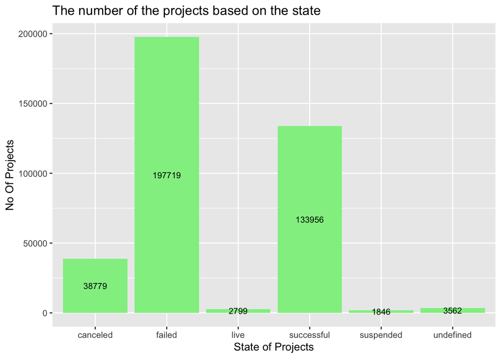

```r
ggplot(kickstarter_status,aes(x=state,y=No_Of_Projects,label=No_Of_Projects)) +
   geom_bar( fill="lightgreen",stat='identity')+
   geom_text(size = 3, position = position_stack(vjust = 0.5))+
    labs( x = 'State of Projects', y = 'No Of Projects')+
  ggtitle('The number of the projects based on the state')
```

As we can see above that 35.38% of the projects were successful. However, 52.22% of the projects were failed. 10.24% of the projects were canceled for unknown reasons. 0.49% of the projects were suspended and 0.94% marked as undefined. In addition, a small percentage of projects were still live at the time of data collection (0.74%).

As the uncompleted projects are representing a small part of the dataset, we will exclude them from our analysis. So, we will focus on the completed projects i.e. successful and failed which represent 331675 projects.

```r
complete_pro <- kickstarter %>%
              filter(state=='successful' | state=='failed')
```

#### Question 2: How many projects for each category? and what is the top projects categories?

```r
kickstarter_cat <- complete_pro %>% group_by(main_category,state) %>%
                                      summarise(No_Of_Projects=n()) %>%
                                      arrange(desc(No_Of_Projects))
datatable(kickstarter_cat)
```

|  | main_category | state | No_Of_Projects |
| --- | --- | --- | --- |
| 1 | Film &amp; Video | failed | 32904 |
| 2 | Music | successful | 24197 |
| 3 | Film &amp; Video | successful | 23623 |
| 4 | Publishing | failed | 23145 |
| 5 | Music | failed | 21752 |
| 6 | Technology | failed | 20616 |
| 7 | Games | failed | 16003 |
| 8 | Food | failed | 15969 |
| 9 | Design | failed | 14814 |
| 10 | Fashion | failed | 14182 |

[output cut: 20 more lines]

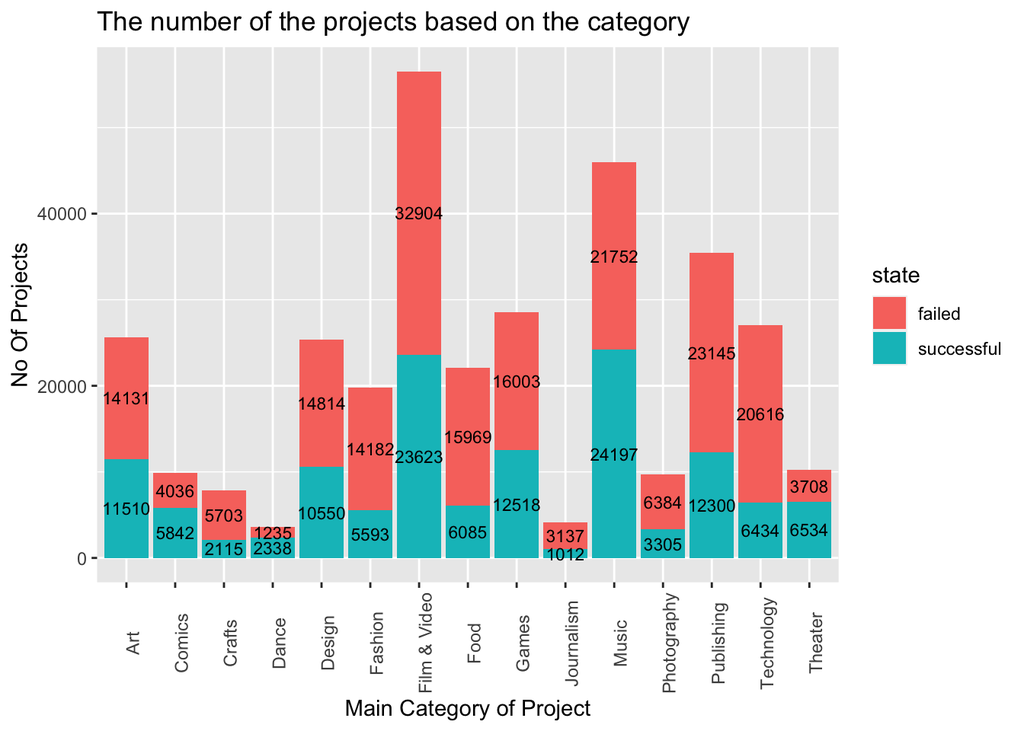

```r
ggplot(kickstarter_cat,aes(x=main_category,y=No_Of_Projects,label=No_Of_Projects,group=state,fill=state)) +
   geom_bar(stat='identity')+
   geom_text(size = 3, position = position_stack(vjust = 0.5))+
    labs( x = 'Main Category of Project', y = 'No Of Projects')+
  theme(axis.text.x = element_text(angle = 90))+
  ggtitle('The number of the projects based on the category')
```

From the plot above we can see that the top three categories are: - Film & Video - Music - Publishing #### Question 3: How many projects per countries?

```r
datatable(complete_pro %>% group_by(country) %>%
                  summarise(No_Of_Projects=n(),Percent_Con=percent(No_Of_Projects/nrow(complete_pro))) %>%
                  arrange(desc(No_Of_Projects)))
```

|  | country | No_Of_Projects | Percent_Con |
| --- | --- | --- | --- |
| 1 | US | 261360 | 79% |
| 2 | GB | 29454 | 9% |
| 3 | CA | 12370 | 4% |
| 4 | AU | 6616 | 2% |
| 5 | DE | 3436 | 1% |
| 6 | FR | 2520 | 1% |
| 7 | NL | 2411 | 1% |
| 8 | IT | 2369 | 1% |
| 9 | ES | 1873 | 1% |
| 10 | SE | 1509 | 0% |

[output cut: 13 more lines]

```r
#datatable(kickstarter_cat)
```

Most of the project were conducted in United states.

#### Question 4: How many projects per year?

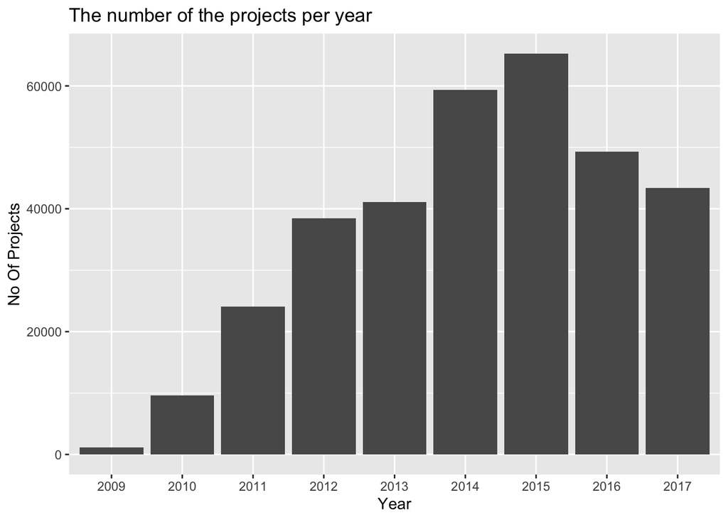

```r
complete_pro %>% group_by(launched_year=format(launched, "%Y")) %>%
                  summarise(No_Of_Projects=n()) %>%
ggplot(.,aes(x=launched_year,y=No_Of_Projects)) +
   geom_bar(stat='identity')+
    labs( x = 'Year', y = 'No Of Projects')+
  ggtitle('The number of the projects per year')
```

From plot above, most projects have been launched in 2015.

#### Question 5: What is effecting the success of project?

Let’s see if the project duration can impact the success of kickstarters projects

```r
complete_pro <- complete_pro %>% mutate(duration=deadline-launched)
state_duration <- complete_pro %>% group_by(duration,state) %>% summarise(No_Successful_Pro=n())
```

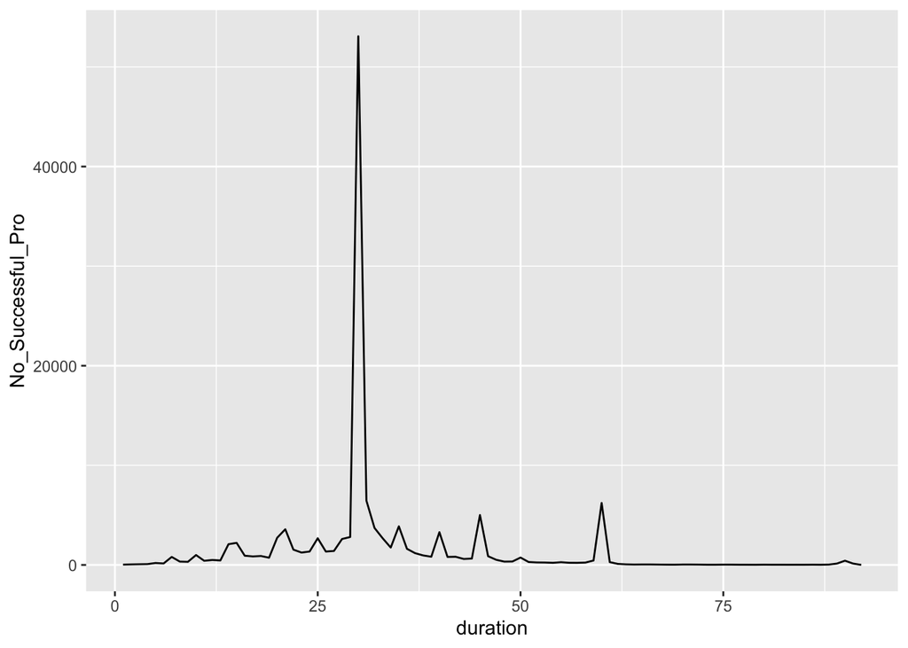

```r
#ggplot(state_duration,aes(x=duration,y=No_Successful_Pro))+
#  geom_point()
state_duration %>% filter(state=='successful') %>%
  ggplot(.,aes(x=duration,y=No_Successful_Pro))+
    geom_line()
```

From plot above, we can see that most of the successful projects take 25 - 35 days.

Since Kickstarter projects are supported by backers, success of projects and amount pledged depend on number of backers. So, let’s see the relationship between the amount pledged and number of backers

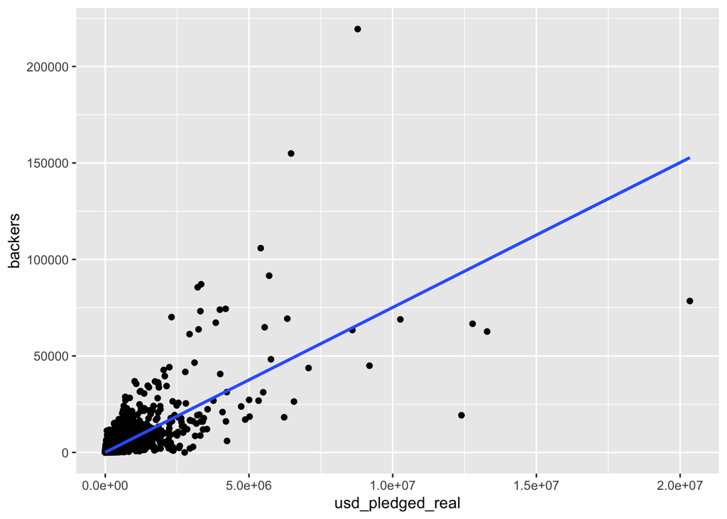

```r
ggplot(complete_pro,aes(x=usd_pledged_real,y=backers))+
  geom_point()+
  stat_smooth(method='lm',se=FALSE)
```

```r
kickstarterlm <- lm(usd_pledged_real~backers,data=complete_pro)
summary(kickstarterlm)
```

```
##
## Call:
## lm(formula = usd_pledged_real ~ backers, data = complete_pro)
##
## Residuals:
##      Min       1Q   Median       3Q      Max
## -7755027    -1822    -1267    -1146 14422882
##
## Coefficients:
##              Estimate Std. Error t value Pr(>|t|)
## (Intercept) 1170.9294   111.4617   10.51   <2e-16 ***
## backers       75.3773     0.1146  657.61   <2e-16 ***
## ---
## Signif. codes:  0 '***' 0.001 '**' 0.01 '*' 0.05 '.' 0.1 ' ' 1
##
## Residual standard error: 63730 on 331673 degrees of freedom
## Multiple R-squared:  0.5659, Adjusted R-squared:  0.5659
## F-statistic: 4.324e+05 on 1 and 331673 DF,  p-value: < 2.2e-16
```

As we can see the p value is <0.05 which means number of backers significantly affects pledged amount. So, a project which is able to attract higher numbers of backers is going to get more money raised.